Towards a  
**new insight**  
of the  
**carbon transport**  
in the  
**global ocean**

# Introduction (1/5)

## Dissolved inorganic carbon (DIC)

Left figure from Friedlingstein et al., (2022)

[figure not shown]

[interactive chart not shown]

DIC = HCO<sub>3</sub><sup>-</sup> + CO<sub>3</sub><sup>2-</sup> + H<sub>2</sub>CO<sub>3</sub> + CO<sub>2</sub> (aq)

## > 200 μmol/kg DIC gradient

[interactive chart not shown]

Not uniform

Source of data: GLODAPv2

## 3 pumps acting against DIC mixing

[interactive chart not shown]

$$\begin{gather*}
pCO_{2}^{water~parcel} = \frac{[CO_{2}]}{K_{0}} \\
K_{0} \approx f(T)
\end{gather*}$$

Cold DIC-enriched waters dive to depth

$$\begin{gather*}
Ca^{2+} + 2HCO_{3}^{-} \rightleftharpoons CaCO_{3} + CO_{2} + H_{2}O
\end{gather*}$$

Precipitation (DIC<sub>surf</sub>↘) vs. dissolution (DIC<sub>deep</sub>↗)

$$\begin{gather*}
CO_{2} + H_{2}O \rightarrow CH_{2}O + O_{2}
\end{gather*}$$

Photosynthesis (DIC<sub>surf</sub>↘) vs. respiration (DIC ↗)

## BCP — 3 export pathways

[figure not shown]

How much organic carbon is exported — How deep is it transported — How long CO<sub>2</sub> is hidden from the atmosphere ?

Figure @ERC-REFINE

## Gravitational pump (BGP)

- Key drivers
- Twilight Zone (TZ) journey

Figure @ERC-REFINE

[figure not shown]

Winter — Low phyto growth  
Spring — Stratification  
Bloom — BGP trigger  
Zoo graze and develop  
Sinking particles  
Fecal pellets (fast)  
Phyto aggregates  
By-products

Figure @ERC-REFINE

[figure not shown]

Animal feeding  
Microbial degradation  
Fragmentation  
…  
Sinking speed  
Residence time  
Depth reached  
Remineralization to CO<sub>2</sub>

## Vertical migration pump (VMP)

- Diel
- Seasonal (lipid pump)

Figure @ERC-REFINE

[figure not shown]

Night — Surface feeding  
Day — Avoid predation  
Metabolize food at depth  
POC injection below EZ  
(e.g. fecal pellets)

Figure @ERC-REFINE

[figure not shown]

Summer — Accumulating  
carbon-rich lipids  
Winter — Diapause (> MLD)  
Survive on reserves  
Release CO<sub>2</sub> at depth  
Sinking of carcasses

## Mixing pump — POC and DOC transport

- Mixed layer
- Eddy-subduction
- Large-scale subduction

Figure @ERC-REFINE

[figure not shown]

1D mechanism  
Mid and high latitudes  
MLD transitions  
Isolation of POC and DOC from the surface

Figure @ERC-REFINE

[figure not shown]

2D mechanism  
Fronts and eddies  
Strong vertical circulation  
days ~ 1-10 km

2D mechanism  
Meridional overturning and Ekman  
Slow advection  
~100-1000 km

## Export range and sequestration time

[interactive chart not shown]

| **Pump** | **POC** | **DOC** | **Sequestration time (years)** **Boyd et al., (2019)** | **Sequestration time (years)** **Nowicki et al., (2022)** |
| --- | --- | --- | --- | --- |
| Gravitational | X |  | ? | 142 |
| Mixing - 20% export flux |  |  |  |  |
| Mixed layer | X | X | 25 - 100 | 54 |
| Eddy subduction | X | X | up to 150 | ? |
| Large-scale subduction | X | X | 25 - 100 | 54 |
| VMP - 10% export flux |  |  |  |  |
| Diel | X |  | up to 250 | 150 |
| Seasonal | X |  | up to 500 | ? |

Large uncertainties remain

## Questions raised so far

How much carbon is exported/injected by each pump?  
How deep is it exported/injected?  
How long is it sequestered from the atmosphere?

Observational framework (Claustre et al., 2021)

Research vessels  
Satellites  
Instrumented moorings  
Floats — gliders — USVs

## Biogeochemical-Argo float (BGC-Argo)

[figure not shown]

## Main objectives of the current work

How much carbon is exported/injected by each pump?  
How deep is it exported/injected?  
How long is it sequestered from the atmosphere?

UVP6 and the zooplankton embedded classification  
Characterization of particles — VMP — Mesopelagic processes

UVP6 and OST deployed in the Labrador Sea  
Two independent measurements of particle and carbon fluxes

Reassessment of global sequestration fluxes by the BCP  
Continuous approach to carbon storage ($\geq$ 100 years)

# UVP6 embedded classification (2/5)

Zooplankton image classification model under strict energy constraints

## Underwater Vision Profilers (UVPs)

[figure not shown]

Since 2008 — UVP5 (small enough for CTD frames)  
2019 — First UVP6 deployments  
2022 — First UVP6 deployments with the embedded classification

## UVP6 — Miniaturized UVP5

Figure @Thomas Boniface

[figure not shown]

0.7L imaged volume  
Particle counter (0.1 - 2.5 mm)  
Particle classifier (> 0.6 mm)  
Particle size distribution (PSD)  
Carbon flux estimations  
Organism studies (e.g VMP)

[figure not shown]

## Why embedded classification?

Image transmission time

Iridium cost  
Biofouling and other hazards  
Power consumption (float battery life)

[figure not shown]

Best image classifier?

Convolutional neural network (CNN)  
State-of-the-art but energy consuming

[figure not shown]

Extreme gradient boosting

Efficient and portable (Chen et al., 2016)

## A features-based classifier called XGBoost

[figure not shown]

Figure from Geron et al. (2019)

Basic principle

Training set = image features  
Left — 3 predictors (decision trees)  
Each one correcting its predecessor  
Right — Ensemble’s prediction

Energy constraints

55 (handcrafted) features  
40 image categories (= labels) max  
Model size (loading time < 700 ms)

## Training set of extracted features

**Image**

**Label**

**Area**

**Mean**

**Eccentricity**

**Orientation angle**

**Hu moment-1**

**50/55**

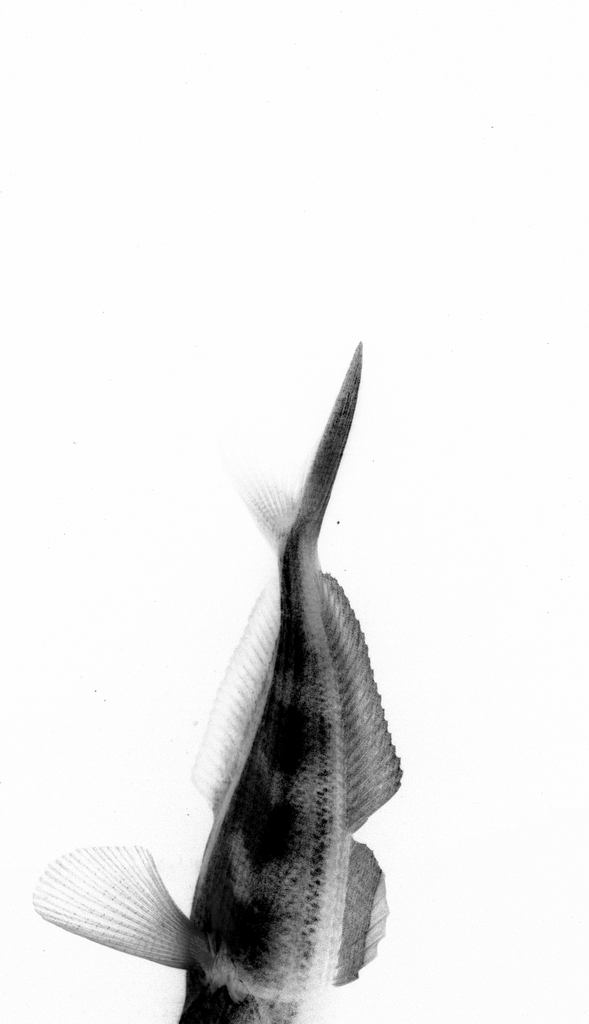

Actinopterygii

210812

157

0.93

-1.38

0.33

...

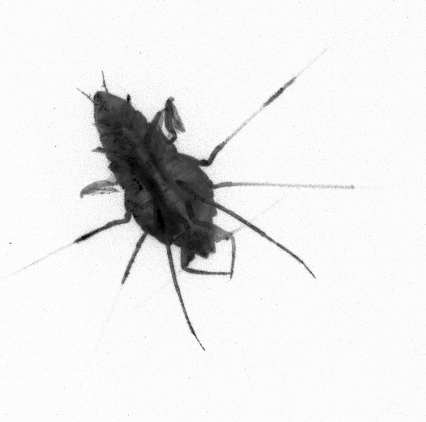

Crustacea

18426

162

0.70

0.88

0.26

...

Calanoida

591

110

0.56

-1.45

0.38

...

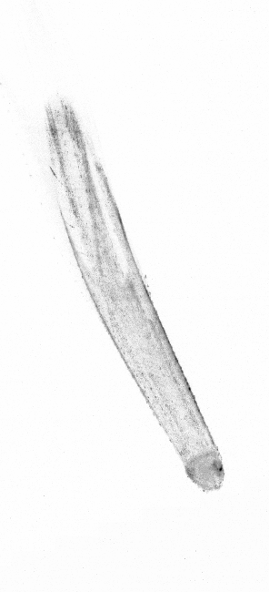

Chaetognatha

18531

53

0.99

1.17

0.81

...

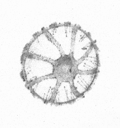

Botrynema

6262

73

0.28

-1.00

0.32

...

Characteristics

Geometry  
Gray levels  
Statistical moments

Model training  
Training set (90%) — test set  
→ Start training

Highest column value

Lowest column value

## 600.000 UVP6 images over +100 labels

- Started training with +100 labels
- Ended up with 20
- Using confusion matrices and good sense

[interactive chart not shown]

40 labels max

90% non-living  
80% detritus

2% Calanoida  
2% Trichodesmium  
6% smaller groups

50 — median class size

[interactive chart not shown]

90% non-living  
80% detritus

2% Trichodesmium  
1% Rhizaria group  
4.5% specific biological groups (2.5% Calanoida)  
2.5% non-specific (other-living)

1000 — median class size

[interactive chart not shown]

Acantharia (test set evaluation)  
TP = 51 — FP (col) = 6 — FN (row) = 23  
Precision = 51/(51+6) = 89%  
Recall (here diagonal) = 51/(51+23) = 69%

Merging labels based on  
precision — recall  
scarcity — confusion  
morphology — ecology

Often wrongly predicted as detritus

## 80% of detritus for 10% of biological groups

- 500k pieces
- Improving biological precision and recall

[figure not shown]

[interactive chart not shown]

Detritus — ubiquitously messy  
Variety of shapes — sizes — gray levels — …

Undersampling  
Quantification  
Clustering (left)  
Continuum in the features space  
Inter-group confusion  
Does not improve biological score  
Add weights on biological classes

## CNN is better but not energy limited

|  | Precision XGBoost | Precision CNN difference | Recall XGBoost | Recall CNN difference | # test set images |  |
| --- | --- | --- | --- | --- | --- | --- |
| Biological groups (5/16) |  |  |  |  |  |  |
| Chaetognatha | 80 |  | 62 |  |  | 57 |
| Foraminifera | 71 |  | 48 |  | 18 |  |
| other<living | 44 |  | 24 |  | 1462 |  |
| puff | 73 |  | 78 |  | 709 |  |
| tuff | 55 |  | 63 |  | 452 |  |
| Non-living (2/4) |  |  |  |  |  |  |
| detritus | 95 |  | 95 |  | 47415 |  |
| fiber | 73 |  | 83 |  | 3212 |  |
| Summary |  |  |  |  |  |  |
| accuracy | 91 |  | 91 |  |  |  |
| macro avg | 76 |  | 68 |  |  |  |
| living macro avg | 73 |  | 63 |  |  |  |
| living weighted avg | 61 |  | 56 |  |  |  |

CNN = higher recall  
Model not limited  
Feature of its own

Carbon fluxes = precision matters  
Focus on living stats  
Need more images of living categories

## Take-home message #1

- Classifying plankton with constraints is challenging
- Imbalanced dataset
  - Detritus are abundant (80%) and highly diverse
  - Living objects are rare
- Room for improvement
  - 20/40 classes in the model
  - New features (e.g. texture)
  - Deal differently with detritus

# UVP6 and OST in the Labrador Sea (3/5)

2 independent measurements of particle and carbon fluxes

## Transmissometer and drifting BGC-Argo

Left figure @Thomas Boniface — right figure @Thomas Haessig (Euro-Argo)

[figure not shown]

## 4 BGC-Argo floats deployed in May 2022

[figure not shown]

▲ Deployment sites  
Last profile  
Deployed in pairs  
Last updated on 01 mai, 2023

## With the Optical Sediment Trap (OST)

Figure @Thomas Boniface

[figure not shown]

Vertical transmissometer

Particle accumulation

$$\begin{gather*}
\small{c_{p} \approx -\frac{ln(T_{r})}{L}, ATN = c_{p} \times L}
\end{gather*}$$

Small (continuous accumulation)  
Large (discontinuous - jumps)

Downward POC flux (BGP)

F<sub>small</sub> & F<sub>large</sub> POC fluxes  
Empirical (Estapa et al., 2023)

## OST used during float drifting

[interactive chart not shown]

Float 6904240 — 21<sup>st</sup> cycle @1000 m  
New statistical jump ( — ) detection approach  
F<sub>small</sub> $\propto$ weighted average ATN slope F<sub>large</sub> $\propto$ sum of positive jumps ()

## New — 3 drifting depths instead of one

[interactive chart not shown]

## UVP6 particle abundance on profiling mode

- 0.1 - 0.5 mm
- 0.5 - 2.5 mm
- Float position

[figure not shown]

Similar patterns across floats  
Unclear particle signature  
Rapid emptying in November  
Particle increase in April

[figure not shown]

Export event?  
1 profile every 10 days

[figure not shown]

## UVP6 particle abundance on drifting mode

- 200 m
- 500 m
- 1000 m
- Float position

[figure not shown]

14 size classes  
Drifting from January to March

[figure not shown]

Drifting from February to March  
Increase in April (bloom ?)

[figure not shown]

Similar measurements across floats  
Latent dynamics of the system?

[figure not shown]

## OST particle flux on drifting mode

- OST
- MLD
- Chlorophyll a
- Float position

[figure not shown]

@1000 m — Similar to UVP6  
Flux attenuation with depth

[figure not shown]

Top — integration over MLD  
Bottom — integration over 100 m

[figure not shown]

## OST vs. UVP6 carbon flux estimations

- Carbon fluxes
- Correlations
- Float position

[figure not shown]

$$\begin{gather*}
F_{total,~OST} = F_{small} + F_{large}
\end{gather*}$$

$$\begin{gather*}
F_{total,~UVP} = \sum_{i}^{N}C_{i}Ad_{i}^{B}
\end{gather*}$$

8 size classes (0.25 - 1.5 mm)

Guidi et al., (2008) — (A, B) = (12.5, 3.81)  
Open ocean sites w/ low carbon fluxes

Iversen et al., (2010) — (A, B) = (273.8, 4.27) Highly productive system (upwelling)

|  | WMO | Small flux 200 m | Small flux 500 m | Small flux 1000 m | Large flux 200 m | Large flux 500 m | Large flux 1000 m | Total flux 200 m | Total flux 500 m | Total flux 1000 m |
| --- | --- | --- | --- | --- | --- | --- | --- | --- | --- | --- |
|  | 6904240 | 0.78 | 0.52 | 0.72 | 0.83 | 0.75 | 0.78 | 0.86 | 0.76 | 0.83 |
|  | 4903634 | 0.67 | 0.77 | 0.78 | 0.81 | 0.66 | 0.87 | 0.84 | 0.70 | 0.87 |
|  | 6904241 | 0.06 | 0.06 | 0.59 | 0.52 | 0.33 | 0.69 | 0.48 | 0.34 | 0.74 |
|  | 1902578 | -0.05 | 0.63 | 0.66 | -0.02 | 0.34 | 0.58 | -0.02 | 0.43 | 0.63 |
| average | — | 0.36 | 0.50 | 0.69 | 0.54 | 0.52 | 0.73 | 0.54 | 0.56 | 0.77 |
| sd | — | 0.42 | 0.31 | 0.08 | 0.40 | 0.22 | 0.12 | 0.41 | 0.20 | 0.11 |

High correlation ($\geq$ 0.7)

Low correlation ($\leq$ 0.2)

→ malfunctioning OST since Nov 2022  
→ float not answering since end of March

[figure not shown]

## Take-home message #2

- OST and UVP6 are well correlated, especially at 1000 m
- Preliminary results (1 year of data)
  - New method for jump detection
  - Guidi (2008) < Labrador Sea < Iversen (2010) ?
- Need to investigate more
  - 3 parking depths — attenuation measurements
  - Environmental conditions (BGC variables)
  - Particle backscattering
  - Nature of particles (embedded classification)

# CONVERSE (4/5)

**CON**tinuous **VE**rtical **SE**questration approach to carbon storage

## BCP and its export pathways

[interactive chart not shown]

POC (all) and DOC (mixing)  
Gravitational settling or injection  
Mixing + VMP merge back with BGP

## Sequestration can occur at any depth

[figure not shown]

Continuous vs. fixed sequestration depth (e.g. 1000 m)  
BCP = BGP + VMP + Mixing pumps transport **F<sub>org</sub>**  
**F<sub>org</sub>** respired to CO<sub>2</sub> (**F<sub>remin</sub>**) or sedimented  
Respiratory CO<sub>2</sub> = biogenic DIC (**DIC<sub>bio</sub>**)  
**DIC<sub>bio</sub>** in the ocean for $\geq$ 100 years = sequestered (**F<sub>seq</sub>**)  
Carbon flux vs. carbon inventory → Pg C year<sup>-1</sup>

Ricour et al., (2023)

## How can we compute F<sub>seq</sub> ?

[figure not shown]

f<sub>100</sub> — *fraction of a water parcel at a given location and depth that will remain in the ocean for $\geq$ 100 years*  
OCIM model (Siegel et al., 2021)  
f<sub>100 (avg)</sub> (530 m) = 0.3  
f<sub>100 (avg)</sub> (> 1000 m) = 0.87

F<sub>seq</sub> = f<sub>100</sub> x F<sub>remin</sub>

## 7 CONVERSE versions to compute F<sub>remin</sub>

| **Version**<sup>1</sup> | **b** | Export depth (m) | Export value (Pg C year<sup>-1</sup>) | **BGP** | **Mixing** | **VMP** |
| --- | --- | --- | --- | --- | --- | --- |
| Group 1 |  |  |  |  |  |  |
| C1 | 0.86 | 100 | 3.0 | empirical | export ratio | empirical |
| C2 | Variable | 100 | 3.0 | empirical | export ratio | empirical |
| C3 | Regional | 100 | 3.0 | empirical | export ratio | empirical |
| Group 2 |  |  |  |  |  |  |
| C4 |  | Zeu | 8.6 | model | model | empirical |
| C5 |  | 100 | 7.3 | model | model | empirical |
| Group 3 |  |  |  |  |  |  |
| C6 | 0.86 | 100 | 3.0 | export ratio | export ratio | empirical |

<sup>1</sup> C7 ~ C1 except for the mixing pump

F<sub>remin</sub> = f(pixel, depth layer, C#)  
BGP empirical — Martin’s flux attenuation curve  
Mixing — 3-in-1  
VMP diel — migration at 300 m  
VMP seasonal — migration at 600 m  
(NNA only)

## Examples of stations — F<sub>remin</sub> x f<sub>100</sub> = F<sub>seq</sub>

[figure not shown]

F<sub>seq</sub> max above 2000 m  
50% of F<sub>seq</sub> accumulation by 1000 m  
Fixed sequestration depth = missing most of F<sub>seq</sub>

## Global F<sub>seq</sub> — continuous vs. fixed depth

[figure not shown]

Magnitudes differ but same patterns

| **F<sub>seq</sub>** | **Min (Pg C y<sup>-1</sup>)** | **Max (Pg C y<sup>-1</sup>)** |
| --- | --- | --- |
| BGP (CONVERSE) | 0.6 | 1.9 |
| BCP (CONVERSE) | 0.9 | 2.6 |
| 1000 m | 0.4 | 1.1 |
| 2000 m | 0.2 | 0.5 |

Mixing — 11-23% of F<sub>seq</sub>(BCP)  
VMP — 9-12% of F<sub>seq</sub>(BCP)

## Take-home message #3

- Sequestration of DIC<sub>bio</sub> not only in deep waters
- Using a fixed sequestration depth underestimate F<sub>seq</sub>(BCP)
  - CONVERSE F<sub>seq</sub>(BCP) = 2-3 > F<sub>seq</sub>(POC, 1000 m)
  - CONVERSE F<sub>seq</sub>(BCP) = 3-6 > F<sub>seq</sub>(POC, 2000 m)
- VMP and Mixing pumps are important contributors to F<sub>seq</sub>(BCP)
  - 21-34%
- CONVERSE could be applied for the evaluation of mCDR strategies

# Perspectives (5/5)

## Application to key biogeochemical regions

- Float position
- UVP6 (0.1 - 0.5 mm)
- UVP6 (0.5 - 2.5 mm)
- UVP6 (200 m)
- UVP6 (500 m)
- UVP6 (1000 m)
- OST drifting
- **Way forward**

[figure not shown]

Kerguelen East  
Kerguelen West  
Labrador Sea  
Subtropical Gyre

[figure not shown]

Kerguelen East  
Kerguelen West  
Labrador Sea  
Subtropical Gyre

[figure not shown]

Kerguelen East  
Kerguelen West  
Labrador Sea  
Subtropical Gyre

[figure not shown]

Kerguelen East  
Kerguelen West  
Labrador Sea  
Subtropical Gyre

[figure not shown]

Kerguelen East  
Kerguelen West  
Labrador Sea  
Subtropical Gyre

[figure not shown]

Kerguelen East  
Kerguelen West  
Labrador Sea  
Subtropical Gyre

- Same method applied on more regions (9)
  - High variability of carbon fluxes in different regions
  - Generalization and reduction of uncertainties
- Investigate POC - OST relationship
- Work on the pump deconvolution
  - Multi-instruments approach

## Application of the UVP6 EC

- Kerguelen Plateau
- **Way forward**

[figure not shown]

- Interpretation with the classification report
  - Precision and recall for each UVP6 class
  - Contextualization
    - Geographical and temporal distribution of species
    - Position in the water column
    - Correlation with the presence of other species
- UVPec
  - Available on GitHub
  - User-friendly toolbox to train alternative UVP6 classification models
  - up to 40 classes